# Validez de constructo con SEM: tres casos con informalidad laboral

Manual de práctica en `lavaan`

12/11/2026

# Presentación

Este manual ilustra con datos simulados tres problemas de **validez de constructo** que suelen pasarse por alto cuando se pasa directamente al cálculo de índices de validez convergente y discriminante. Los tres usan la **informalidad laboral** como constructo:

| Caso | Pregunta | Fuente de evidencia de validez (*Standards*, 2014) |
| --- | --- | --- |
| 1 | ¿Hay otro factor que explique varianza sistemática en los indicadores? (independencia local) | Estructura interna |
| 2 | ¿El constructo se representa mejor con una o con varias dimensiones? | Estructura interna / validez discriminante |
| 3 | ¿El constructo predice lo que la teoría dice, **condicional** en los controles? | Relaciones con otras variables (red nomológica) |

**Organización de los archivos**

- `generar_datos.R`: simula todas las bases y guarda los parámetros verdaderos en `data/`. Contiene el proceso generador de datos (PGD), que conviene discutir con el grupo **después** de cada caso.
- `manual_validez_sem.Rmd` (este archivo): sólo lee los datos y los analiza, como haría un investigador que no conoce el PGD.

```r
library(lavaan)    # >= 0.6
library(semTools)  # htmt(), AVE(), compRelSEM()
library(knitr)
library(semPlot)   # diagramas: install.packages("semPlot")

# Diagrama de trayectorias con la solución estandarizada
#   layout   = "tree" (vertical), "tree2" (mejor para bifactor/estructural)
#   rotation = 1 (arriba-abajo), 2 (izquierda-derecha)
#   bifactor = nombre del factor general (dibuja los específicos del otro lado)
diagrama <- function(fit, titulo = "", layout = "tree", rotation = 1,
                     bifactor = NULL, ...) {
  semPaths(fit, what = "std", whatLabels = "std",
           layout = layout, rotation = rotation, bifactor = bifactor,
           style = "lisrel", residuals = TRUE, intercepts = FALSE,
           thresholds = FALSE, nCharNodes = 0,
           shapeMan = "rectangle", sizeMan = 11, sizeMan2 = 4, sizeLat = 8,
           label.cex = 1, edge.label.cex = 0.9, edge.color = "black",
           fade = FALSE, mar = c(5, 4, 6, 4), ...)
  title(titulo, line = 2.5)
}

if (!file.exists("data/parametros_verdaderos.rds"))
  stop("Primero ejecute: source('generar_datos.R')")

verdad <- readRDS("data/parametros_verdaderos.rds")

# Auxiliares para tablas
ajuste <- function(fit, nombre = deparse(substitute(fit))) {
  fm <- fitMeasures(fit, c("chisq", "df", "pvalue", "cfi", "tli",
                           "rmsea", "srmr", "aic", "bic"))
  v <- setNames(round(as.numeric(fm), 3), names(fm))
  data.frame(modelo = nombre, as.list(v), check.names = FALSE)
}
cargas_std <- function(fit) {
  ss <- standardizedSolution(fit)
  ss <- ss[ss$op == "=~", c("lhs", "rhs", "est.std")]
  names(ss) <- c("factor", "indicador", "carga_std")
  ss
}
```

> **Nota sobre los indicadores.** En encuestas de empleo (ENOE, por ejemplo) los indicadores de informalidad son binarios. Para concentrarnos en la lógica, el cuerpo del manual usa sus **respuestas latentes continuas** ($y^*$). El Apéndice repite el Caso 1 con indicadores binarios y el estimador WLSMV.

# 1 Caso 1. Pérdida de independencia local

## 1.1 Idea

En un modelo factorial reflexivo de un factor,

$$x_j = \lambda_j\,\eta + \varepsilon_j,
\qquad \operatorname{Cov}(\varepsilon_j,\varepsilon_k)=0 \;\; (j\neq
k),$$

lo que implica $\operatorname{Cov}(x_j, x_k) = \lambda_j \lambda_k \operatorname{Var}(\eta)$. Esto es la **independencia local**: *condicional en* $\eta$, los indicadores no covarían. Toda la covarianza sistemática entre los indicadores se debe al constructo.

Si un **segundo factor**, ajeno al constructo, afecta a un subconjunto de indicadores, la independencia local se rompe. El problema no es sólo estadístico. El puntaje resultante mezcla el constructo con **varianza sistemática irrelevante para el constructo** (Messick), y el factor estimado puede quedar *redefinido* por los datos.

**Ejemplo.** Medimos informalidad con seis indicadores. Tres de ellos (no tener contrato escrito, recibir el pago en efectivo, unidad económica sin registro fiscal) dependen también de ser **trabajador por cuenta propia**. Un trabajador independiente no tiene contrato con un patrón y cobra en efectivo a sus clientes, aunque en el sentido teórico no sea “más informal”.

## 1.2 Los datos

```r
d1 <- read.csv("data/c1_dependencia_local.csv")
round(cor(d1), 2)
```

```
             sin_ss sin_salud sin_prest sin_contrato pago_efec sin_registro
sin_ss         1.00      0.61      0.57         0.43      0.38         0.40
sin_salud      0.61      1.00      0.53         0.43      0.38         0.38
sin_prest      0.57      0.53      1.00         0.39      0.35         0.34
sin_contrato   0.43      0.43      0.39         1.00      0.61         0.56
pago_efec      0.38      0.38      0.35         0.61      1.00         0.56
sin_registro   0.40      0.38      0.34         0.56      0.56         1.00
```

La matriz ya sugiere una estructura en bloques: las correlaciones dentro de `sin_contrato`, `pago_efec` y `sin_registro` son más altas de lo que sus correlaciones con los demás indicadores harían esperar.

## 1.3 Modelo 1: un factor (independencia local impuesta)

```r
m1_uni <- '
  INF =~ sin_ss + sin_salud + sin_prest + sin_contrato + pago_efec + sin_registro
'
f1_uni <- cfa(m1_uni, data = d1, std.lv = TRUE)
kable(ajuste(f1_uni, "1 factor"))
```

| modelo | chisq | df | pvalue | cfi | tli | rmsea | srmr | aic | bic |
| --- | --- | --- | --- | --- | --- | --- | --- | --- | --- |
| 1 factor | 674.004 | 9 | 0 | 0.852 | 0.753 | 0.192 | 0.077 | 30166.44 | 30233.65 |

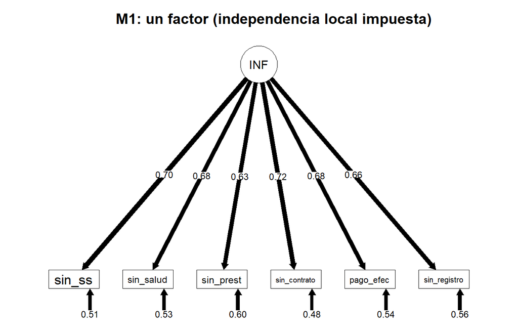

```r
diagrama(f1_uni, "M1: un factor (independencia local impuesta)")
```

El ajuste es malo (RMSEA y CFI lejos de los umbrales usuales). Lo informativo no es el índice global sino **dónde** está el desajuste. Los residuos de correlación (observada − implicada) muestran el patrón:

```r
res1 <- lavResiduals(f1_uni)$cov
round(res1, 3)
```

```
             sin_ss sn_sld sn_prs sn_cnt pag_fc sn_rgs
sin_ss        0.000
sin_salud     0.131  0.000
sin_prest     0.125  0.097  0.000
sin_contrato -0.073 -0.063 -0.068  0.000
pago_efec    -0.090 -0.080 -0.081  0.121  0.000
sin_registro -0.066 -0.072 -0.077  0.084  0.109  0.000
```

- Residuos **positivos** dentro de {`sin_ss`, `sin_salud`, `sin_prest`} y dentro de {`sin_contrato`, `pago_efec`, `sin_registro`}.
- Residuos **negativos** entre bloques.

Es la huella de un factor omitido. Ahora veamos los índices de modificación:

```r
mi1 <- modindices(f1_uni, sort. = TRUE)
head(mi1[, c("lhs", "op", "rhs", "mi", "sepc.all")], 6)
```

|  | lhs | op | rhs | mi | sepc.all |
| --- | --- | --- | --- | --- | --- |
| 14 | sin_ss |  | sin_salud | 217.42546 | 0.4345481 |
| 26 | sin_contrato |  | pago_efec | 207.93023 | 0.4358547 |
| 15 | sin_ss |  | sin_prest | 160.34072 | 0.3560001 |
| 28 | pago_efec |  | sin_registro | 124.99478 | 0.3157121 |
| 17 | sin_ss |  | pago_efec | 99.97133 | -0.2930049 |
| 27 | sin_contrato |  | sin_registro | 92.29132 | 0.2847287 |

**Atención:** el índice de modificación más grande puede **no** estar en los indicadores contaminados sino en los “limpios” (`sin_ss ~~ sin_salud`, etc.). La covarianza adicional de los tres indicadores contractuales *jala* al factor hacia ellos. El factor queda redefinido y los indicadores de protección social quedan con covarianza no explicada. Liberar mecánicamente el IM más grande llevaría a una corrección equivocada.

## 1.4 Modelo 2: informalidad + factor de autoempleo

```r
m1_bif <- '
  INF  =~ sin_ss + sin_salud + sin_prest + sin_contrato + pago_efec + sin_registro
  AUTO =~ sin_contrato + pago_efec + sin_registro
  INF ~~ 0*AUTO          # factor ajeno, ortogonal al constructo
'
f1_bif <- cfa(m1_bif, data = d1, std.lv = TRUE)
```

## 1.5 Modelo 3: un factor + residuos correlacionados

```r
m1_res <- '
  INF =~ sin_ss + sin_salud + sin_prest + sin_contrato + pago_efec + sin_registro
  sin_contrato ~~ pago_efec + sin_registro
  pago_efec    ~~ sin_registro
'
f1_res <- cfa(m1_res, data = d1, std.lv = TRUE)

kable(rbind(ajuste(f1_uni, "M1: 1 factor"),
            ajuste(f1_bif, "M2: INF + AUTO"),
            ajuste(f1_res, "M3: 1 factor + resid. corr.")))
```

| modelo | chisq | df | pvalue | cfi | tli | rmsea | srmr | aic | bic |
| --- | --- | --- | --- | --- | --- | --- | --- | --- | --- |
| M1: 1 factor | 674.004 | 9 | 0.000 | 0.852 | 0.753 | 0.192 | 0.077 | 30166.44 | 30233.65 |
| M2: INF + AUTO | 3.108 | 6 | 0.795 | 1.000 | 1.002 | 0.000 | 0.005 | 29501.54 | 29585.55 |
| M3: 1 factor + resid. corr. | 3.108 | 6 | 0.795 | 1.000 | 1.002 | 0.000 | 0.005 | 29501.54 | 29585.55 |

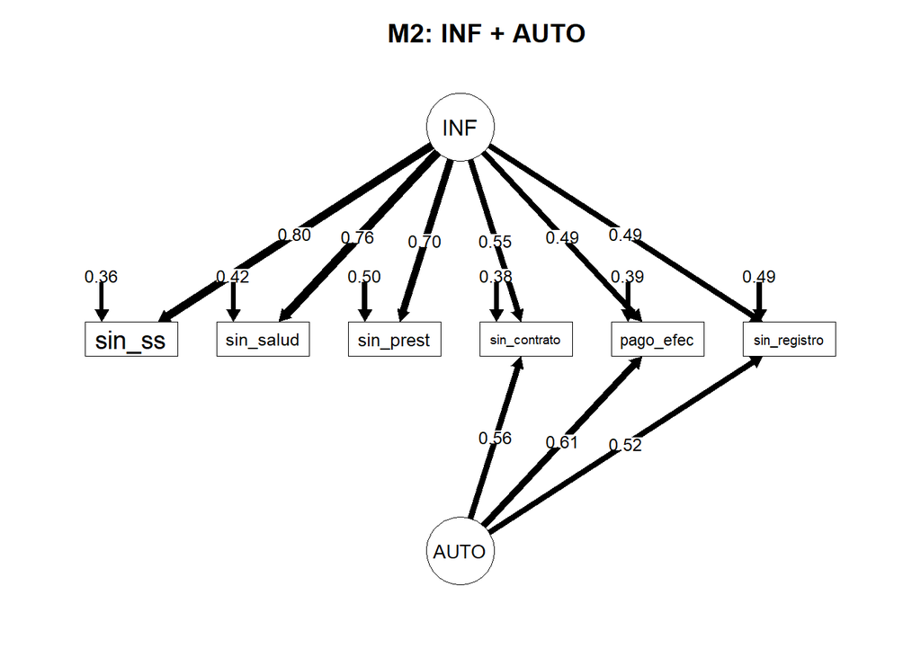

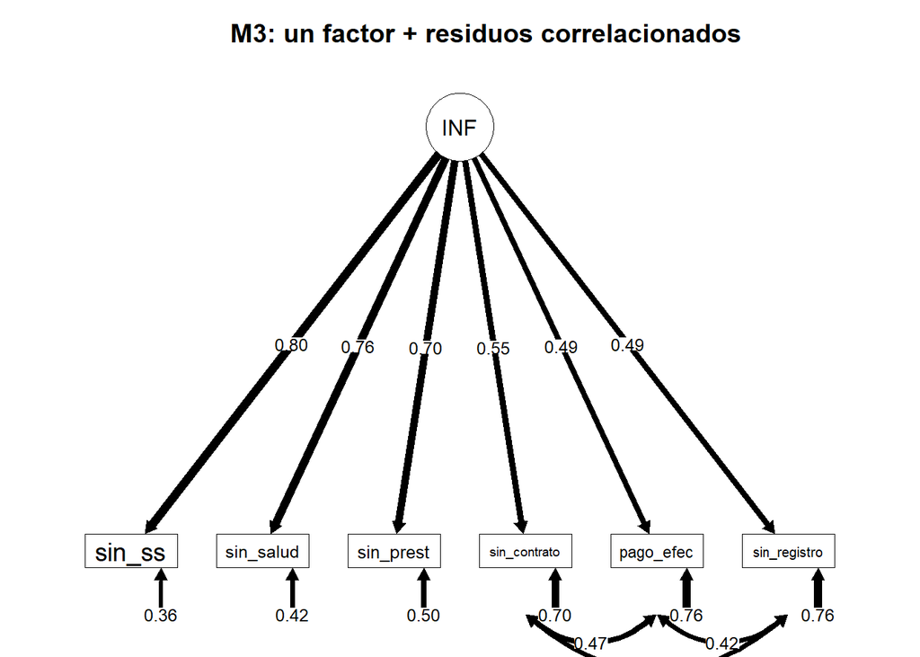

```r
diagrama(f1_bif, "M2: INF + AUTO", layout = "tree2", bifactor = "INF",
         exoCov = FALSE)   # oculta la covarianza INF ~~ AUTO fijada en 0
diagrama(f1_res, "M3: un factor + residuos correlacionados")
```

Los diagramas muestran la equivalencia. En M2 la covarianza extra entre `sin_contrato`, `pago_efec` y `sin_registro` pasa por un factor; en M3, por tres arcos entre sus errores.

M2 y M3 son **modelos equivalentes**: tienen el mismo $\chi^2$ y los mismos grados de libertad. Un factor específico con tres indicadores consume exactamente los tres parámetros que liberan las tres covarianzas residuales. Los datos no distinguen entre “artefacto de método” (M3) y “segundo factor sustantivo” (M2). **Esa decisión es teórica**, y es precisamente una decisión sobre la validez del constructo.

## 1.6 Consecuencias: cargas y fiabilidad

```r
v1 <- verdad$cargas_c1
comp <- data.frame(
  indicador       = rownames(v1),
  verdadera_INF   = v1[, "INF"],
  M1_1factor      = cargas_std(f1_uni)$carga_std,
  M2_INF          = subset(cargas_std(f1_bif), factor == "INF")$carga_std,
  verdadera_AUTO  = v1[, "AUTO"],
  M2_AUTO         = c(0, 0, 0, subset(cargas_std(f1_bif), factor == "AUTO")$carga_std)
)
kable(comp, digits = 2, row.names = FALSE)
```

| indicador | verdadera_INF | M1_1factor | M2_INF | verdadera_AUTO | M2_AUTO |
| --- | --- | --- | --- | --- | --- |
| sin_ss | 0.80 | 0.70 | 0.80 | 0.00 | 0.00 |
| sin_salud | 0.75 | 0.68 | 0.76 | 0.00 | 0.00 |
| sin_prest | 0.70 | 0.63 | 0.70 | 0.00 | 0.00 |
| sin_contrato | 0.55 | 0.72 | 0.55 | 0.55 | 0.56 |
| pago_efec | 0.50 | 0.68 | 0.49 | 0.60 | 0.61 |
| sin_registro | 0.50 | 0.66 | 0.49 | 0.50 | 0.52 |

En el modelo de un factor, las cargas de los indicadores contaminados se **inflan** (quedan iguales o mayores que las de protección social) y las de protección social se **atenúan**. En el proceso verdadero, los indicadores de protección social son los mejores indicadores de informalidad. El modelo mal especificado invierte el orden.

### 1.6.1 Error total y error sistemático por indicador

Con indicadores estandarizados, la varianza de cada indicador se descompone en

$$1 =
\underbrace{\lambda_{INF}^2}_{\text{válida}} \;+\;
\underbrace{\lambda_{AUTO}^2}_{\text{sistemática irrelevante}} \;+\;
\underbrace{\theta}_{\text{aleatoria}},
\qquad \text{error total} = 1-\lambda_{INF}^2 = \lambda_{AUTO}^2 +
\theta .$$

A partir de esta descomposición se definen medidas concretas por indicador:

| Medida | Fórmula | Interpretación |
| --- | --- | --- |
| Coeficiente de validez | $\lambda_{INF}$ | Correlación del indicador con el constructo |
| Varianza válida | $\lambda_{INF}^2$ | Parte de la varianza que es informalidad |
| Varianza sistemática irrelevante | $\lambda_{AUTO}^2$ | Error **sistemático**: confiable pero ajeno al constructo |
| Varianza aleatoria | $\theta$ | Error aleatorio |
| Fiabilidad | $\lambda_{INF}^2+\lambda_{AUTO}^2$ | Todo lo sistemático, relevante o no |
| Error total | $1-\lambda_{INF}^2$ | Todo lo que no es constructo |
| Proporción sistemática del error | $\lambda_{AUTO}^2/(1-\lambda_{INF}^2)$ | Qué parte del error total *no* se promedia al sumar indicadores |

La brecha entre fiabilidad y varianza válida ($\lambda_{AUTO}^2$) es exactamente el error sistemático.

```r
v1     <- verdad$cargas_c1
items1 <- rownames(v1)

# Cargas estandarizadas de M2, alineadas por indicador
cb <- cargas_std(f1_bif)
lam_inf_m2 <- setNames(cb$carga_std[cb$factor == "INF"],
                       cb$indicador[cb$factor == "INF"])[items1]
lam_aut_m2 <- setNames(rep(0, length(items1)), items1)
sel <- cb$factor == "AUTO"
lam_aut_m2[cb$indicador[sel]] <- cb$carga_std[sel]

descomponer <- function(l_inf, l_aut) {
  data.frame(
    indicador          = items1,
    validez            = l_inf,
    var_valida         = l_inf^2,
    var_sist_irrel     = l_aut^2,
    var_aleatoria      = 1 - l_inf^2 - l_aut^2,
    fiabilidad         = l_inf^2 + l_aut^2,
    error_total        = 1 - l_inf^2,
    prop_sist_en_error = l_aut^2 / (1 - l_inf^2),
    row.names = NULL
  )
}

kable(descomponer(v1[, "INF"], v1[, "AUTO"]), digits = 3,
      caption = "Proceso verdadero (sólo conocido en la simulación)")
```

Proceso verdadero (sólo conocido en la simulación)

| indicador | validez | var_valida | var_sist_irrel | var_aleatoria | fiabilidad | error_total | prop_sist_en_error |
| --- | --- | --- | --- | --- | --- | --- | --- |
| sin_ss | 0.80 | 0.640 | 0.000 | 0.360 | 0.640 | 0.360 | 0.000 |
| sin_salud | 0.75 | 0.562 | 0.000 | 0.438 | 0.562 | 0.438 | 0.000 |
| sin_prest | 0.70 | 0.490 | 0.000 | 0.510 | 0.490 | 0.510 | 0.000 |
| sin_contrato | 0.55 | 0.303 | 0.303 | 0.395 | 0.605 | 0.698 | 0.434 |
| pago_efec | 0.50 | 0.250 | 0.360 | 0.390 | 0.610 | 0.750 | 0.480 |
| sin_registro | 0.50 | 0.250 | 0.250 | 0.500 | 0.500 | 0.750 | 0.333 |

```r
kable(descomponer(lam_inf_m2, lam_aut_m2), digits = 3,
      caption = "Estimado con M2 (lo que el investigador puede calcular)")
```

Estimado con M2 (lo que el investigador puede calcular)

| indicador | validez | var_valida | var_sist_irrel | var_aleatoria | fiabilidad | error_total | prop_sist_en_error |
| --- | --- | --- | --- | --- | --- | --- | --- |
| sin_ss | 0.798 | 0.637 | 0.000 | 0.363 | 0.637 | 0.363 | 0.000 |
| sin_salud | 0.763 | 0.582 | 0.000 | 0.418 | 0.582 | 0.418 | 0.000 |
| sin_prest | 0.704 | 0.495 | 0.000 | 0.505 | 0.495 | 0.505 | 0.000 |
| sin_contrato | 0.552 | 0.305 | 0.312 | 0.384 | 0.616 | 0.695 | 0.448 |
| pago_efec | 0.493 | 0.243 | 0.370 | 0.387 | 0.613 | 0.757 | 0.489 |
| sin_registro | 0.494 | 0.244 | 0.267 | 0.488 | 0.512 | 0.756 | 0.354 |

M2 recupera la descomposición verdadera. En los indicadores contractuales, entre un tercio y la mitad del error total es **sistemático**. Su fiabilidad es similar a la de los indicadores de protección social, pero su validez es mucho menor.

¿Qué concluiría quien estimara sólo el modelo de un factor (M1)? M1 no tiene forma de separar la varianza sistemática irrelevante: la reparte entre “constructo” y “residuo”.

```r
cm1    <- cargas_std(f1_uni)
lam_m1 <- setNames(cm1$carga_std, cm1$indicador)[items1]
lam_v  <- v1[, "INF"]

m1_vs_verdad <- data.frame(
  indicador             = items1,
  carga_M1              = lam_m1,
  carga_verdadera       = lam_v,
  sesgo                 = lam_m1 - lam_v,
  sesgo_rel_pct         = 100 * (lam_m1 - lam_v) / lam_v,
  rango_M1              = rank(-lam_m1),
  rango_verdadero       = rank(-lam_v),
  error_total_M1        = 1 - lam_m1^2,
  error_total_verdadero = 1 - lam_v^2,
  var_mal_clasificada   = lam_m1^2 - lam_v^2,
  row.names = NULL
)
kable(m1_vs_verdad, digits = 3)
```

| indicador | carga_M1 | carga_verdadera | sesgo | sesgo_rel_pct | rango_M1 | rango_verdadero | error_total_M1 | error_total_verdadero | var_mal_clasificada |
| --- | --- | --- | --- | --- | --- | --- | --- | --- | --- |
| sin_ss | 0.698 | 0.80 | -0.102 | -12.771 | 2 | 1.0 | 0.513 | 0.360 | -0.153 |
| sin_salud | 0.685 | 0.75 | -0.065 | -8.722 | 3 | 2.0 | 0.531 | 0.438 | -0.094 |
| sin_prest | 0.633 | 0.70 | -0.067 | -9.512 | 6 | 3.0 | 0.599 | 0.510 | -0.089 |
| sin_contrato | 0.722 | 0.55 | 0.172 | 31.271 | 1 | 4.0 | 0.479 | 0.698 | 0.219 |
| pago_efec | 0.679 | 0.50 | 0.179 | 35.881 | 4 | 5.5 | 0.538 | 0.750 | 0.212 |
| sin_registro | 0.661 | 0.50 | 0.161 | 32.237 | 5 | 5.5 | 0.563 | 0.750 | 0.187 |

- `var_mal_clasificada` **> 0**: varianza sistemática irrelevante que M1 cuenta como informalidad. Ocurre en los indicadores contaminados.
- `var_mal_clasificada` **< 0**: varianza válida que M1 cuenta como error. Ocurre en los indicadores de protección social, porque el factor se desplazó hacia los contaminados.
- En los indicadores contaminados, M1 subestima el error total en promedio en 0.21 unidades de varianza estandarizada. En los de protección social lo sobreestima en 0.11. Las columnas de rango muestran la inversión del orden.

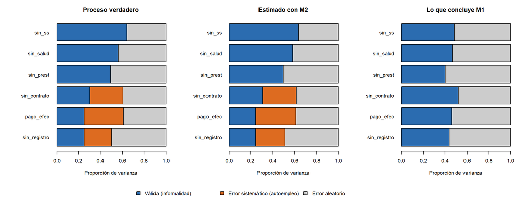

```r
cols  <- c("#2b6cb0", "#dd6b20", "grey80")
comps <- function(v, s, a) {
  m <- rbind(v, s, a); colnames(m) <- items1; m[, rev(seq_along(items1))]
}
layout(matrix(c(1, 2, 3, 4, 4, 4), 2, byrow = TRUE), heights = c(5, 1))
op <- par(mar = c(4, 9, 3, 1))
barplot(comps(lam_v^2, v1[, "AUTO"]^2, 1 - lam_v^2 - v1[, "AUTO"]^2),
        horiz = TRUE, las = 1, col = cols,
        xlab = "Proporción de varianza", main = "Proceso verdadero")
barplot(comps(lam_inf_m2^2, lam_aut_m2^2, 1 - lam_inf_m2^2 - lam_aut_m2^2),
        horiz = TRUE, las = 1, col = cols,
        xlab = "Proporción de varianza", main = "Estimado con M2")
barplot(comps(lam_m1^2, rep(0, 6), 1 - lam_m1^2),
        horiz = TRUE, las = 1, col = cols,
        xlab = "Proporción de varianza", main = "Lo que concluye M1")
par(mar = c(0, 0, 0, 0)); plot.new()
legend("center", horiz = TRUE, bty = "n", fill = cols,
       legend = c("Válida (informalidad)", "Error sistemático (autoempleo)",
                  "Error aleatorio"))
```

```r
par(op); layout(1)
```

M1 no tiene una categoría para el error sistemático. Lo reparte entre la barra azul de los indicadores contaminados, que se alarga, y la gris.

### 1.6.2 Fiabilidad del puntaje: $\omega_t$ y $\omega_h$

¿Cuánto de la varianza confiable del puntaje sumado es realmente informalidad? Usamos el modelo M2 para calcular $\omega$ total y $\omega$ jerárquico:

$$\omega_t = \frac{(\sum\lambda_{INF})^2 +
(\sum\lambda_{AUTO})^2}{\operatorname{Var}(X)}, \qquad
\omega_h =
\frac{(\sum\lambda_{INF})^2}{\operatorname{Var}(X)}$$

```r
ss2   <- standardizedSolution(f1_bif)
l_inf <- ss2$est.std[ss2$lhs == "INF"  & ss2$op == "=~"]
l_aut <- ss2$est.std[ss2$lhs == "AUTO" & ss2$op == "=~"]
theta <- ss2$est.std[ss2$op == "~~" & ss2$lhs == ss2$rhs & ss2$lhs %in% names(d1)]
var_X <- sum(l_inf)^2 + sum(l_aut)^2 + sum(theta)

fiab <- data.frame(
  medida = c("alfa de Cronbach (tau-equivalente)",
             "omega (modelo de 1 factor, M1)",
             "omega total (M2)",
             "omega jerárquico: sólo INF (M2)",
             "proporción de varianza común debida a AUTO"),
  valor = c(compRelSEM(f1_uni, tau.eq = TRUE),
            compRelSEM(f1_uni),
            (sum(l_inf)^2 + sum(l_aut)^2) / var_X,
            sum(l_inf)^2 / var_X,
            sum(l_aut)^2 / (sum(l_inf)^2 + sum(l_aut)^2))
)
kable(fiab, digits = 3)
```

| medida | valor |
| --- | --- |
| alfa de Cronbach (tau-equivalente) | 0.837 |
| omega (modelo de 1 factor, M1) | 0.838 |
| omega total (M2) | 0.872 |
| omega jerárquico: sólo INF (M2) | 0.729 |
| proporción de varianza común debida a AUTO | 0.164 |

Alfa y omega de un factor son altos y “aprobarían” la escala. Pero una parte de esa varianza confiable es **autoempleo**, no informalidad. **Fiabilidad no es validez:** la varianza sistemática irrelevante es perfectamente confiable.

## 1.7 Para discutir

1. ¿Qué otras fuentes de varianza sistemática podrían afectar a subconjuntos de indicadores de informalidad? Por ejemplo: tamaño de la empresa, sector agropecuario, informante *proxy* en el hogar, módulo del cuestionario.
2. ¿Cuándo es preferible modelar `AUTO` como factor (M2) y cuándo como residuos correlacionados (M3)? ¿Cambia la interpretación del puntaje?
3. Si `AUTO` estuviera correlacionado con `INF` (lo más realista), ¿qué problemas de identificación aparecerían? ¿Qué información externa ayudaría?

# 2 Caso 2. ¿Una dimensión o dos?

## 2.1 Idea

Supongamos que la teoría propone dos dimensiones de la informalidad:

- **PROT, protección social**: `sin_ss`, `sin_salud`, `sin_prest`
- **LEGAL, legal-contractual**: `sin_contrato`, `pago_efec`, `sin_registro`

El modelo de dos factores correlacionados **siempre** ajusta al menos tan bien como el de un factor, porque el modelo de un factor es un caso particular del de dos con $\rho_{PROT,LEGAL}=1$. Una mejora de ajuste no basta para justificar la multidimensionalidad. La pregunta relevante es si las dimensiones son **empíricamente distinguibles**, es decir, si hay evidencia de validez discriminante entre ellas.

Analizamos dos bases:

- **(a)** `c2_unidimensional.csv`: los datos provienen de *un* factor.
- **(b)** `c2_contraste_bidimensional.csv`: hay dos factores reales y moderadamente correlacionados.

```r
m2_uni <- '
  INF =~ sin_ss + sin_salud + sin_prest + sin_contrato + pago_efec + sin_registro
'
m2_bi <- '
  PROT  =~ sin_ss + sin_salud + sin_prest
  LEGAL =~ sin_contrato + pago_efec + sin_registro
'
d2a <- read.csv("data/c2_unidimensional.csv")
d2b <- read.csv("data/c2_contraste_bidimensional.csv")

f2a_uni <- cfa(m2_uni, data = d2a, std.lv = TRUE)
f2a_bi  <- cfa(m2_bi,  data = d2a, std.lv = TRUE)
f2b_uni <- cfa(m2_uni, data = d2b, std.lv = TRUE)
f2b_bi  <- cfa(m2_bi,  data = d2b, std.lv = TRUE)
```

## 2.2 (a) Datos unidimensionales

```r
kable(rbind(ajuste(f2a_uni, "1 factor"), ajuste(f2a_bi, "2 factores")))
```

| modelo | chisq | df | pvalue | cfi | tli | rmsea | srmr | aic | bic |
| --- | --- | --- | --- | --- | --- | --- | --- | --- | --- |
| 1 factor | 17.397 | 9 | 0.043 | 0.998 | 0.997 | 0.022 | 0.01 | 29589.34 | 29656.55 |
| 2 factores | 17.332 | 8 | 0.027 | 0.998 | 0.996 | 0.024 | 0.01 | 29591.28 | 29664.09 |

```r
lavTestLRT(f2a_uni, f2a_bi)
```

|  | Df | AIC | BIC | Chisq | Chisq diff | RMSEA | Df diff | Pr(>Chisq) |
| --- | --- | --- | --- | --- | --- | --- | --- | --- |
| f2a_bi | 8 | 29591.28 | 29664.09 | 17.33205 | NA | NA | NA | NA |
| f2a_uni | 9 | 29589.34 | 29656.55 | 17.39702 | 0.0649634 | 0 | 1 | 0.7988164 |

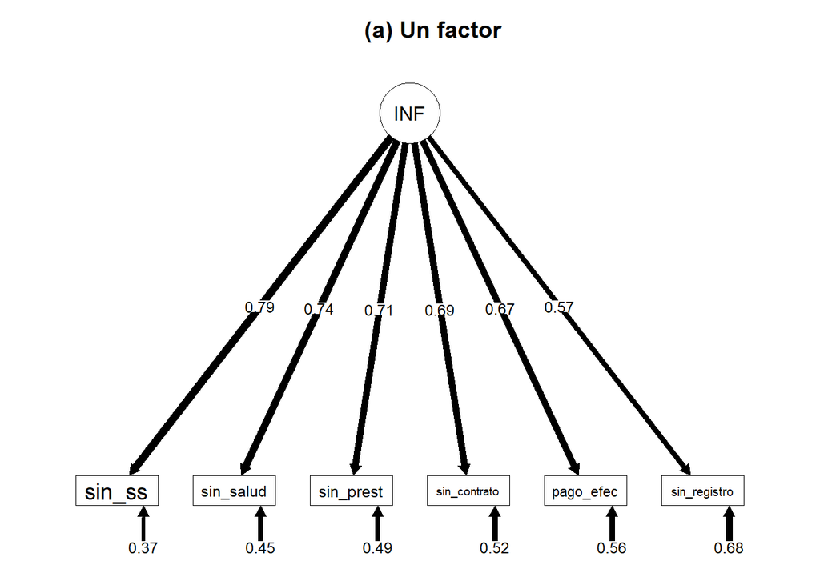

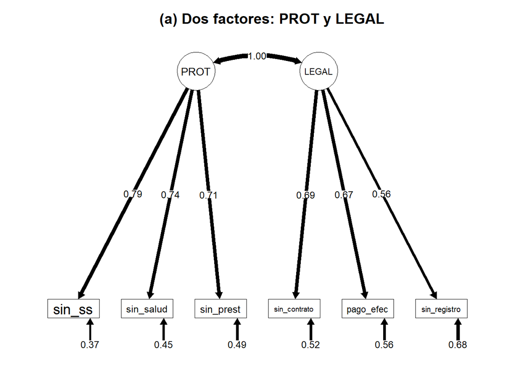

```r
diagrama(f2a_uni, "(a) Un factor")
diagrama(f2a_bi,  "(a) Dos factores: PROT y LEGAL")
```

Fíjese en el arco entre `PROT` y `LEGAL` del segundo diagrama.

Ambos modelos ajustan bien. La diferencia de $\chi^2$ (1 gl) no es significativa, y AIC/BIC favorecen al modelo de un factor. Veamos la correlación latente:

```r
rho_a <- subset(parameterEstimates(f2a_bi), lhs == "PROT" & rhs == "LEGAL")
rho_a[, c("lhs", "rhs", "est", "se", "ci.lower", "ci.upper")]
```

|  | lhs | rhs | est | se | ci.lower | ci.upper |
| --- | --- | --- | --- | --- | --- | --- |
| 15 | PROT | LEGAL | 1.003273 | 0.0128304 | 0.9781253 | 1.02842 |

La correlación entre “dimensiones” es prácticamente 1 y su intervalo de confianza incluye el 1. Si la estimación puntual rebasa 1, `lavaan` advierte que la matriz de covarianzas latentes **no es definida positiva** (un caso Heywood). Esa advertencia no es un problema técnico que haya que “arreglar”: es evidencia de que los dos factores no se distinguen. La prueba de razón de verosimilitud de arriba es, de hecho, la prueba de $H_0:\rho=1$. Como $\rho=1$ está en la frontera del espacio paramétrico, la prueba es conservadora.

**Criterios habituales de validez discriminante entre PROT y LEGAL:**

```r
htmt_a <- htmt(m2_bi, data = d2a)
ave_a  <- AVE(f2a_bi)
data.frame(
  criterio = c("rho latente", "rho^2", "AVE PROT", "AVE LEGAL", "HTMT"),
  valor    = round(c(rho_a$est, rho_a$est^2, ave_a, htmt_a["LEGAL", "PROT"]), 3),
  regla    = c("IC no debe incluir 1 (o umbral .80-.90)",
               "Fornell-Larcker: rho^2 < AVE de ambos",
               "", "", "< .85 (o .90)")
)
```

| criterio | valor | regla |
| --- | --- | --- |
| rho latente | 1.003 | IC no debe incluir 1 (o umbral .80-.90) |
| rho^2 | 1.007 | Fornell-Larcker: rho^2 < AVE de ambos |
| AVE PROT | 0.560 |  |
| AVE LEGAL | 0.414 |  |
| HTMT | 1.002 | < .85 (o .90) |

Todos los criterios coinciden: **no hay validez discriminante** entre las supuestas dimensiones. Reportar dos subíndices sería un caso de *jangle fallacy*: dos nombres para lo mismo, con el riesgo de que el análisis de política trate como distintos dos indicadores que no lo son.

Nótese también que el AVE de LEGAL puede quedar por debajo de .50 aunque el modelo sea correcto. El AVE refleja la **magnitud** de las cargas, no la dimensionalidad. Ésta es una razón para no usarlo como criterio mecánico de validez convergente.

## 2.3 (b) Contraste: dos dimensiones reales

```r
kable(rbind(ajuste(f2b_uni, "1 factor"), ajuste(f2b_bi, "2 factores")))
```

| modelo | chisq | df | pvalue | cfi | tli | rmsea | srmr | aic | bic |
| --- | --- | --- | --- | --- | --- | --- | --- | --- | --- |
| 1 factor | 652.946 | 9 | 0.000 | 0.775 | 0.625 | 0.189 | 0.115 | 31708.99 | 31776.2 |
| 2 factores | 8.447 | 8 | 0.391 | 1.000 | 1.000 | 0.005 | 0.012 | 31066.49 | 31139.3 |

```r
lavTestLRT(f2b_uni, f2b_bi)
```

|  | Df | AIC | BIC | Chisq | Chisq diff | RMSEA | Df diff | Pr(>Chisq) |
| --- | --- | --- | --- | --- | --- | --- | --- | --- |
| f2b_bi | 8 | 31066.49 | 31139.3 | 8.447433 | NA | NA | NA | NA |
| f2b_uni | 9 | 31708.99 | 31776.2 | 652.946362 | 644.4989 | 0.5672296 | 1 | 0 |

```r
rho_b <- subset(parameterEstimates(f2b_bi), lhs == "PROT" & rhs == "LEGAL")
htmt_b <- htmt(m2_bi, data = d2b)
```

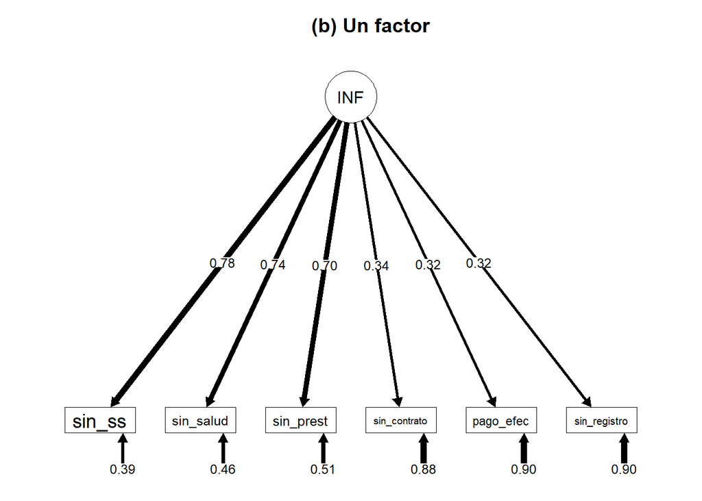

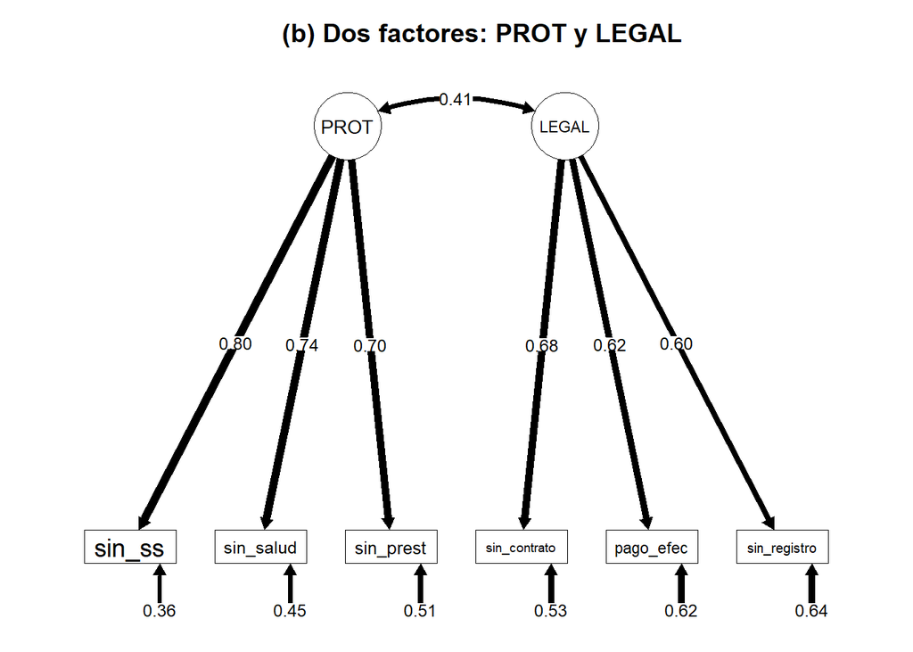

```r
diagrama(f2b_uni, "(b) Un factor")
diagrama(f2b_bi,  "(b) Dos factores: PROT y LEGAL")
```

Aquí el modelo de un factor se rechaza con claridad. La correlación latente es 0.41 (IC 95 %: 0.36–0.47) y el HTMT es 0.42. La distinción entre dimensiones tiene respaldo empírico.

## 2.4 Resumen del Caso 2

```r
resumen2 <- data.frame(
  base         = c("(a) unidimensional", "(b) bidimensional"),
  rho_real     = c(1, verdad$rho_contraste),
  rho_estimado = c(rho_a$est, rho_b$est),
  IC_sup       = c(rho_a$ci.upper, rho_b$ci.upper),
  HTMT         = c(htmt_a["LEGAL", "PROT"], htmt_b["LEGAL", "PROT"]),
  p_LRT        = c(lavTestLRT(f2a_uni, f2a_bi)[2, "Pr(>Chisq)"],
                   lavTestLRT(f2b_uni, f2b_bi)[2, "Pr(>Chisq)"]),
  BIC_prefiere = c(ifelse(BIC(f2a_uni) < BIC(f2a_bi), "1 factor", "2 factores"),
                   ifelse(BIC(f2b_uni) < BIC(f2b_bi), "1 factor", "2 factores"))
)
kable(resumen2, digits = 3)
```

| base | rho_real | rho_estimado | IC_sup | HTMT | p_LRT | BIC_prefiere |
| --- | --- | --- | --- | --- | --- | --- |
| (a) unidimensional | 1.00 | 1.003 | 1.028 | 1.002 | 0.799 | 1 factor |
| (b) bidimensional | 0.45 | 0.415 | 0.468 | 0.424 | 0.000 | 2 factores |

## 2.5 Para discutir

1. Si la teoría (o la definición de la OIT) distingue conceptualmente entre protección social y condición legal, ¿basta la evidencia de (a) para abandonar la distinción? ¿Qué diferencia hay entre distinción *conceptual* y *empírica*?
2. ¿Por qué el CFI/RMSEA del modelo de dos factores en (a) no es un argumento a su favor?
3. ¿Qué pasaría con la conclusión si $N$ fuera 200 en lugar de 2000? (Sugerencia: modifique `N` en `generar_datos.R` y vuelva a compilar.)

# 3 Caso 3. Validez nomológica: predicción condicional

## 3.1 Idea

Un constructo válido debe ocupar el lugar que la teoría le asigna en su **red nomológica** (Cronbach y Meehl, 1955). Para un economista, la predicción natural es una **penalización salarial por informalidad** en una ecuación tipo Mincer:

$$\ln w_i = \beta_0 +
\beta_1\,\text{educ}_i + \beta_2\,\text{exper}_i +
\beta_3\,\text{exper}^2_i
+ \beta_4\,\text{mujer}_i + \beta_{INF}\,\text{INF}_i + u_i, \qquad
\beta_{INF} < 0.$$

El punto clave es que la predicción es **condicional**. La informalidad se concentra en trabajadores con menor escolaridad, de modo que cualquier variable correlacionada con la escolaridad “predice” salarios sin condicionar. La evidencia de validez está en que el constructo prediga **después** de controlar por capital humano.

Con SEM estimamos la relación al nivel latente, corregida por error de medición:

```
INF =~ indicadores                 (modelo de medida)
INF ~ educ + exper + mujer         (MIMIC: determinantes de la informalidad)
ln_w ~ INF + educ + exper + exper2 + mujer
```

Comparamos dos escenarios:

- **(a)** Los indicadores son laborales y miden informalidad.
- **(b)** Un “índice de informalidad” se construye con indicadores del **hogar** (sin acceso a salud por ninguna vía, uso de efectivo, sin cuenta bancaria, sin internet, vivienda precaria, sin crédito). Estos indicadores miden algo más cercano a **marginación**, muy ligado a la escolaridad.

En ambos casos el salario verdadero tiene una penalización de -0.25 log-puntos por desviación estándar de informalidad.

```r
d3a <- read.csv("data/c3a_informalidad_salarios.csv")
d3b <- read.csv("data/c3b_marginacion_salarios.csv")
items_a <- c("sin_ss", "sin_salud", "sin_prest", "sin_contrato", "pago_efec", "sin_registro")
items_b <- c("sin_salud_hogar", "usa_efectivo", "sin_cuenta", "sin_internet",
             "viv_precaria", "sin_credito")

modelos_c3 <- function(items) {
  medida <- paste("F =~", paste(items, collapse = " + "))
  list(
    medida        = medida,
    incondicional = paste(medida, "\n ln_w ~ F"),
    condicional   = paste(medida, "
      F    ~ educ + exper + mujer
      ln_w ~ F + educ + exper + exper2 + mujer")
  )
}
ma <- modelos_c3(items_a)
mb <- modelos_c3(items_b)
cat(ma$condicional)
```

```
F =~ sin_ss + sin_salud + sin_prest + sin_contrato + pago_efec + sin_registro
      F    ~ educ + exper + mujer
      ln_w ~ F + educ + exper + exper2 + mujer
```

## 3.2 (a) Indicadores laborales de informalidad

```r
f3a_med  <- cfa(ma$medida,        data = d3a)
f3a_inc  <- sem(ma$incondicional, data = d3a)
f3a_cond <- sem(ma$condicional,   data = d3a)
kable(rbind(ajuste(f3a_med, "medida"), ajuste(f3a_cond, "estructural condicional")))
```

| modelo | chisq | df | pvalue | cfi | tli | rmsea | srmr | aic | bic |
| --- | --- | --- | --- | --- | --- | --- | --- | --- | --- |
| medida | 3.520 | 9 | 0.94 | 1.000 | 1.002 | 0.000 | 0.004 | 29387.93 | 29455.14 |
| estructural condicional | 38.353 | 35 | 0.32 | 0.999 | 0.999 | 0.007 | 0.011 | 31685.51 | 31803.13 |

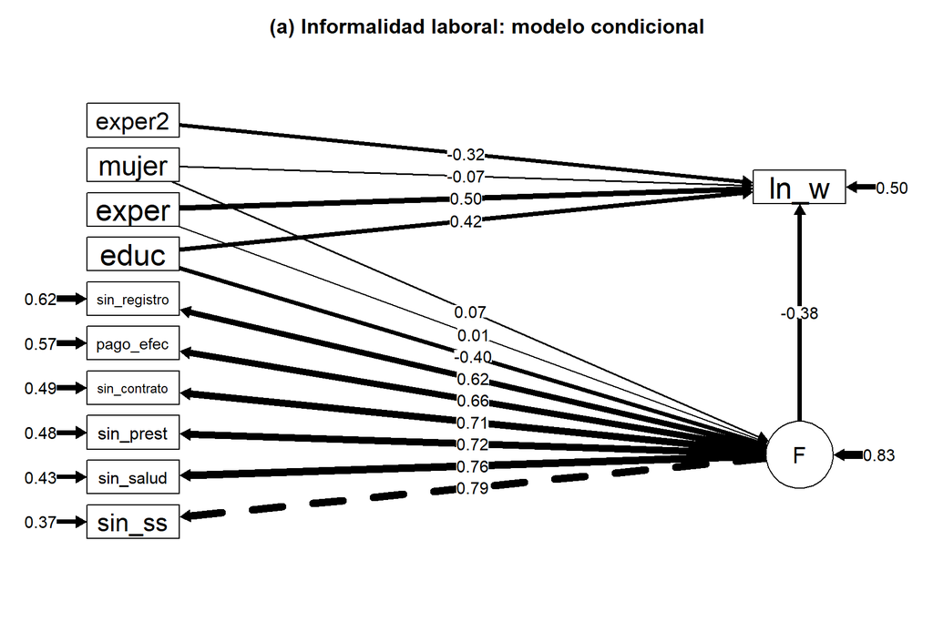

```r
diagrama(f3a_cond, "(a) Informalidad laboral: modelo condicional",
         layout = "tree2", rotation = 2, exoCov = FALSE)
```

El diagrama muestra la solución **completamente estandarizada** (`std.all`). Las tablas de abajo reportan la solución `std.lv`, con $\ln w$ en log-puntos.

Efecto de una DE de la informalidad latente sobre $\ln w$ (solución `std.lv`, que estandariza la latente pero deja $\ln w$ en log-puntos):

```r
efecto <- function(fit, etiqueta) {
  s <- standardizedSolution(fit, type = "std.lv")
  s <- s[s$lhs == "ln_w" & s$op == "~" & s$rhs == "F", ]
  data.frame(especificacion = etiqueta, estimacion = s$est.std,
             ic_inf = s$ci.lower, ic_sup = s$ci.upper)
}
# Comparación con enfoques "observados" habituales
reg_obs <- function(d, x, etiqueta) {
  d$z <- as.vector(scale(x))
  m <- lm(ln_w ~ z + educ + exper + exper2 + mujer, data = d)
  ci <- confint(m)["z", ]
  data.frame(especificacion = etiqueta, estimacion = coef(m)["z"],
             ic_inf = ci[1], ic_sup = ci[2], row.names = NULL)
}
tab3a <- rbind(
  efecto(f3a_inc,  "SEM sin controles"),
  efecto(f3a_cond, "SEM condicional"),
  reg_obs(d3a, rowSums(d3a[items_a]), "MCO condicional: suma de indicadores"),
  reg_obs(d3a, d3a$sin_ss,            "MCO condicional: sólo sin_ss"),
  data.frame(especificacion = "Valor verdadero", estimacion = verdad$beta_INF,
             ic_inf = NA, ic_sup = NA)
)
kable(tab3a, digits = 3, row.names = FALSE)
```

| especificacion | estimacion | ic_inf | ic_sup |
| --- | --- | --- | --- |
| SEM sin controles | -0.352 | -0.379 | -0.324 |
| SEM condicional | -0.240 | -0.265 | -0.215 |
| MCO condicional: suma de indicadores | -0.219 | -0.241 | -0.197 |
| MCO condicional: sólo sin_ss | -0.165 | -0.187 | -0.143 |
| Valor verdadero | -0.250 | NA | NA |

- **Sin controles**, el efecto está sobreestimado en valor absoluto: incluye la correlación entre informalidad y escolaridad.
- **SEM condicional** recupera la penalización verdadera. Es evidencia a favor de la validez nomológica de la medida.
- Los enfoques con variables **observadas** quedan atenuados por el error de medición (más con un solo indicador). La atenuación se agrava al condicionar: los controles absorben parte de la varianza verdadera del constructo pero no la del error, de modo que la fiabilidad del componente residual es menor que la fiabilidad marginal.

## 3.3 (b) Un índice que no mide lo que dice medir

```r
f3b_med  <- cfa(mb$medida,        data = d3b)
f3b_inc  <- sem(mb$incondicional, data = d3b)
f3b_cond <- sem(mb$condicional,   data = d3b)
kable(rbind(ajuste(f3b_med, "medida"), ajuste(f3b_cond, "estructural condicional")))
```

| modelo | chisq | df | pvalue | cfi | tli | rmsea | srmr | aic | bic |
| --- | --- | --- | --- | --- | --- | --- | --- | --- | --- |
| medida | 5.539 | 9 | 0.785 | 1.000 | 1.001 | 0.000 | 0.006 | 29504.60 | 29571.81 |
| estructural condicional | 40.438 | 35 | 0.243 | 0.999 | 0.999 | 0.009 | 0.009 | 31089.21 | 31206.83 |

```r
kable(data.frame(omega = compRelSEM(f3b_med), AVE = AVE(f3b_med)), digits = 3)
```

|  | omega | AVE |
| --- | --- | --- |
| F | 0.8552165 | 0.4987627 |

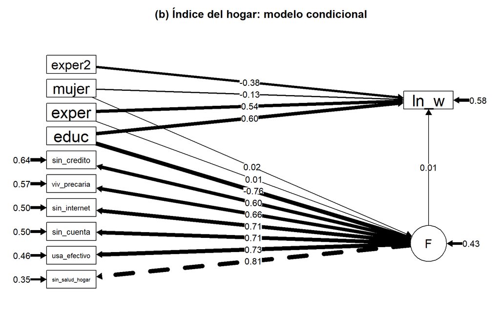

```r
diagrama(f3b_cond, "(b) Índice del hogar: modelo condicional",
         layout = "tree2", rotation = 2, exoCov = FALSE)
```

Compare con el diagrama de (a): aquí la flecha `educ → F` es mucho más fuerte y la flecha `F → ln_w` es prácticamente cero.

Con los criterios usuales de estructura interna, el índice **pasa**: ajuste excelente, cargas altas, omega de 0.86 y AVE de 0.5, en el umbral habitual de .50.

```r
tab3b <- rbind(
  efecto(f3b_inc,  "SEM sin controles"),
  efecto(f3b_cond, "SEM condicional"),
  reg_obs(d3b, rowSums(d3b[items_b]), "MCO condicional: suma de indicadores"),
  data.frame(especificacion = "Penalización teórica esperada", estimacion = verdad$beta_INF,
             ic_inf = NA, ic_sup = NA)
)
kable(tab3b, digits = 3, row.names = FALSE)
```

| especificacion | estimacion | ic_inf | ic_sup |
| --- | --- | --- | --- |
| SEM sin controles | -0.297 | -0.327 | -0.268 |
| SEM condicional | 0.008 | -0.031 | 0.047 |
| MCO condicional: suma de indicadores | 0.003 | -0.028 | 0.034 |
| Penalización teórica esperada | -0.250 | NA | NA |

Sin controles, el “índice de informalidad” predice salarios con el signo esperado y con una magnitud similar a la del escenario (a). Un análisis apresurado lo tomaría como evidencia de validez de criterio. **Condicional en el capital humano, el efecto desaparece.** ¿Por qué? Veamos los determinantes del factor:

```r
r2 <- data.frame(
  escenario = c("(a) informalidad laboral", "(b) índice del hogar"),
  coef_educ_std = c(
    subset(standardizedSolution(f3a_cond), lhs == "F" & rhs == "educ")$est.std,
    subset(standardizedSolution(f3b_cond), lhs == "F" & rhs == "educ")$est.std),
  R2_factor = c(lavInspect(f3a_cond, "r2")["F"], lavInspect(f3b_cond, "r2")["F"])
)
kable(r2, digits = 3)
```

| escenario | coef_educ_std | R2_factor |
| --- | --- | --- |
| (a) informalidad laboral | -0.402 | 0.166 |
| (b) índice del hogar | -0.756 | 0.573 |

El factor del escenario (b) es, en buena medida, una aproximación a la escolaridad. Su asociación con el salario pasa por el capital humano, no por la informalidad. La **estructura interna correcta no garantiza la validez**: el factor existe y se mide con precisión, pero no es el constructo que la teoría necesita.

## 3.4 Precauciones al usar la predicción condicional como evidencia

- La prueba es tan buena como la teoría. Un efecto nulo puede indicar mala medición o una teoría equivocada (p. ej., ausencia de penalización en ciertos mercados). Conviene contar con varias predicciones de la red nomológica: duración del empleo, acceso a crédito, volatilidad del ingreso.
- El modelo MIMIC supone que los controles afectan a los indicadores **sólo a través del factor**. Los efectos directos (p. ej., `mujer → sin_prest`) son no invariancia y deben revisarse con `modindices()` o con modelos multigrupo.
- Hay que evitar el **sobrecontrol**: no condicionar en variables que son consecuencia de la informalidad (p. ej., horas trabajadas o tipo de ocupación, si se determinan a la vez).
- Aquí el PGD está diseñado para que la relación sea “causal”. Con datos reales, la penalización por informalidad es objeto de debate (selección, heterogeneidad). Para validar la medida importa que la asociación condicional tenga el signo y la magnitud que predice la teoría, no identificar el efecto causal.

## 3.5 Para discutir

1. ¿Qué otras variables de la red nomológica de la informalidad podrían usarse como evidencia convergente o discriminante?
2. Combine los casos 1 y 3: si el factor de autoempleo afectara también al salario, ¿qué le pasaría a $\hat\beta_{INF}$ en un modelo que ignora `AUTO`?
3. ¿Por qué la atenuación del índice sumado es mayor en la regresión condicional que en la incondicional?

# Síntesis

| Lección | Caso |
| --- | --- |
| La independencia local es un supuesto **sustantivo**: su violación introduce varianza sistemática irrelevante al constructo y redefine el factor. | 1 |
| Los índices de modificación muestran síntomas, no causas. Modelos equivalentes requieren decisiones teóricas. | 1 |
| Fiabilidad (alfa, omega) alta no implica validez. | 1, 3b |
| El error de medición tiene un componente aleatorio, que se promedia al agregar indicadores, y uno sistemático, que no se promedia. Conviene reportar ambos por indicador y por puntaje. | 1 |
| Más dimensiones siempre ajustan igual o mejor; la multidimensionalidad requiere validez discriminante entre dimensiones. | 2 |
| El AVE mide la magnitud de las cargas, no la dimensionalidad ni la validez. | 2 |
| La evidencia de “relaciones con otras variables” debe ser **condicional** a lo que la teoría controla, y estimarse a nivel latente para evitar atenuación. | 3 |

# Apéndice: Caso 1 con indicadores binarios (WLSMV)

```r
d1_bin <- read.csv("data/c1_dependencia_local_binaria.csv")
colMeans(d1_bin)   # prevalencias
```

```
      sin_ss    sin_salud    sin_prest sin_contrato    pago_efec sin_registro
      0.5500       0.5700       0.5890       0.5325       0.4750       0.5075
```

```r
f1_uni_bin <- cfa(m1_uni, data = d1_bin, ordered = TRUE, std.lv = TRUE)
f1_bif_bin <- cfa(m1_bif, data = d1_bin, ordered = TRUE, std.lv = TRUE)

ajuste_esc <- function(fit, nombre) {
  fm <- fitMeasures(fit, c("chisq.scaled", "df.scaled", "pvalue.scaled",
                           "cfi.scaled", "rmsea.scaled", "srmr"))
  v <- setNames(round(as.numeric(fm), 3), names(fm))
  data.frame(modelo = nombre, as.list(v), check.names = FALSE)
}
kable(rbind(ajuste_esc(f1_uni_bin, "1 factor"), ajuste_esc(f1_bif_bin, "INF + AUTO")))
```

| modelo | chisq.scaled | df.scaled | pvalue.scaled | cfi.scaled | rmsea.scaled | srmr |
| --- | --- | --- | --- | --- | --- | --- |
| 1 factor | 203.083 | 9 | 0.000 | 0.945 | 0.104 | 0.072 |
| INF + AUTO | 5.600 | 6 | 0.469 | 1.000 | 0.000 | 0.012 |

```r
lavTestLRT(f1_uni_bin, f1_bif_bin)   # diferencia de chi^2 ajustada (DIFFTEST)
```

|  | Df | AIC | BIC | Chisq | Chisq diff | Df diff | Pr(>Chisq) |
| --- | --- | --- | --- | --- | --- | --- | --- |
| f1_bif_bin | 6 | NA | NA | 2.982435 | NA | NA | NA |
| f1_uni_bin | 9 | NA | NA | 132.436465 | 153.3901 | 3 | 0 |

```r
kable(merge(cargas_std(f1_uni_bin), cargas_std(f1_bif_bin),
            by = c("factor", "indicador"), all = TRUE,
            suffixes = c("_1factor", "_bifactor")), digits = 2)
```

| factor | indicador | carga_std_1factor | carga_std_bifactor |
| --- | --- | --- | --- |
| AUTO | pago_efec | NA | 0.62 |
| AUTO | sin_contrato | NA | 0.52 |
| AUTO | sin_registro | NA | 0.47 |
| INF | pago_efec | 0.70 | 0.51 |
| INF | sin_contrato | 0.73 | 0.57 |
| INF | sin_prest | 0.64 | 0.70 |
| INF | sin_registro | 0.69 | 0.55 |
| INF | sin_salud | 0.70 | 0.76 |
| INF | sin_ss | 0.73 | 0.80 |

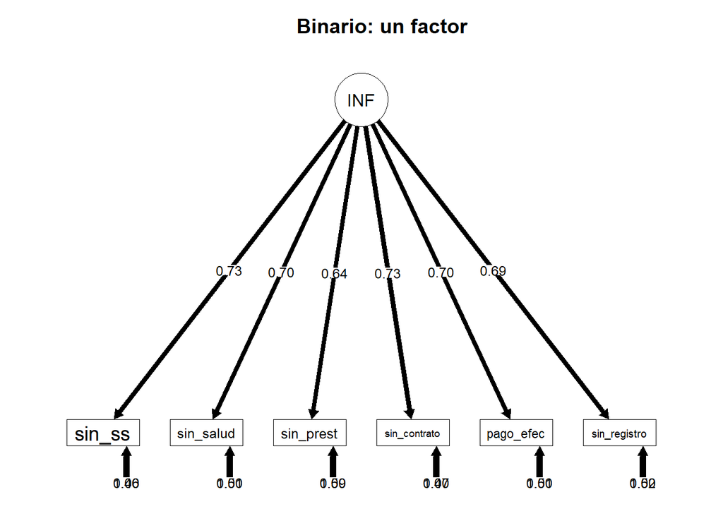

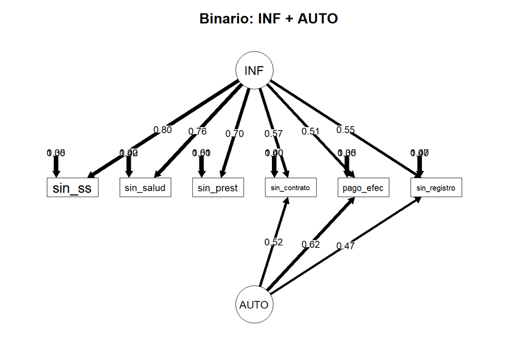

```r
diagrama(f1_uni_bin, "Binario: un factor")
diagrama(f1_bif_bin, "Binario: INF + AUTO", layout = "tree2",
         bifactor = "INF", exoCov = FALSE)
```

Las conclusiones se mantienen con indicadores binarios: el modelo de un factor desajusta y sobrecarga los indicadores contractuales. Con indicadores binarios, las cargas estandarizadas se refieren a las respuestas latentes $y^*$ (correlaciones tetracóricas).

# Referencias

- AERA, APA y NCME (2014). *Standards for Educational and Psychological Testing*.
- Cronbach, L. J. y Meehl, P. E. (1955). Construct validity in psychological tests. *Psychological Bulletin*, 52, 281–302.
- Campbell, D. T. y Fiske, D. W. (1959). Convergent and discriminant validation by the multitrait-multimethod matrix. *Psychological Bulletin*, 56, 81–105.
- Messick, S. (1995). Validity of psychological assessment. *American Psychologist*, 50, 741–749.
- Fornell, C. y Larcker, D. F. (1981). Evaluating structural equation models with unobservable variables and measurement error. *Journal of Marketing Research*, 18, 39–50.
- Henseler, J., Ringle, C. M. y Sarstedt, M. (2015). A new criterion for assessing discriminant validity in variance-based SEM. *Journal of the Academy of Marketing Science*, 43, 115–135.
- Rönkkö, M. y Cho, E. (2022). An updated guideline for assessing discriminant validity. *Organizational Research Methods*, 25, 6–47.
- Reise, S. P. (2012). The rediscovery of bifactor measurement models. *Multivariate Behavioral Research*, 47, 667–696.
- Bollen, K. A. (1989). *Structural Equations with Latent Variables*. Wiley.